**Geog 315 T1 2022**

# Introducing the data

First you need to load the `sf` library for handling spatial data, `tmap` for mapping, and `dplyr` for data wrangling.

```r
library(sf)
library(tmap)
library(dplyr)
```

The data for this week are election results from the US Presidential Election of 2016 (the one that gave us president Donald J. Trump). I’m sticking with that election because the data are more interesting than in 2020.

The data are at the county level for the US (over 3000 counties of wildly varying populations), with numbers of votes recorded for the two major parties—Democrat (`dem`) and Republican (`gop`)— along with some other minor parties: Libertarian (`lib`), Green (`grn`), Evan McMullin (`una`) and ‘Other’ (`oth`).

You will find the data in the this geopackage file. Download it and save it to an accessible folder on the computer you are working on (this will be **on the H: drive** if you are on a lab computer). Then create a new *RStudio* project in that folder like you learned last week.

Then you can read the data using the `st_read` function

```r
results <- st_read('election.gpkg')
```

To make sure all is as it should be, take a look at the first few rows of the data using the `head` function

```r
head(results)
```

```
## Simple feature collection with 6 features and 10 fields
## Geometry type: MULTIPOLYGON
## Dimension:     XY
## Bounding box:  xmin: 761051.8 ymin: 828012.4 xmax: 1026128 ymax: 1287748
## Projected CRS: Albers
##   state    name population votes   dem   gop grn  lib una oth
## 1    AL Autauga      54571 24661  5908 18110 105  538   0   0
## 2    AL Baldwin     182265 94090 18409 72780 453 2448   0   0
## 3    AL Barbour      27457 10390  4848  5431  18   93   0   0
## 4    AL    Bibb      22915  8748  1874  6733  17  124   0   0
## 5    AL  Blount      57322 25384  2150 22808  89  337   0   0
## 6    AL Bullock      10914  4701  3530  1139  10   22   0   0
##                             geom
## 1 MULTIPOLYGON (((892112.8 11...
## 2 MULTIPOLYGON (((780232.6 94...
## 3 MULTIPOLYGON (((1026128 105...
## 4 MULTIPOLYGON (((845034.9 11...
## 5 MULTIPOLYGON (((871035.6 12...
## 6 MULTIPOLYGON (((988752.8 10...
```

[By the way, there is also a `tail` function.] You can also see the dataset by clicking on it in the **Environment** tab of *RStudio*. If you want to make sure the spatial aspects are working OK, then try

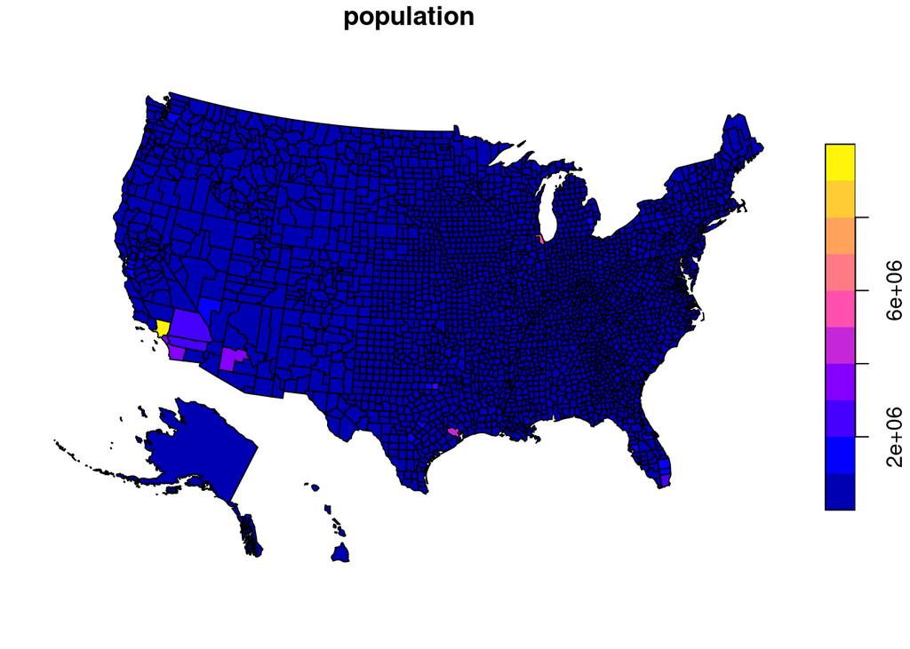

```r
select(results, population) %>% plot()
```

OK… the goal eventually will be to make a map of the election results. Here, I’ll explain the variables in the dataset.

The spatial units are US counties. Each county is in a particular state and has a name. This information is contained in the `state` and `name` attributes. The state’s each have a two letter abbreviation, as shown on [this map](https://en.wikipedia.org/wiki/List_of_U.S._state_abbreviations#Postal_codes), so for example, California is ‘CA’. Not all counties have unique names, so we need the state names to uniquely identify them. For example

```r
results %>%
  filter(name == 'Washington')
```

```
## Simple feature collection with 32 features and 10 fields
## Geometry type: MULTIPOLYGON
## Dimension:     XY
## Bounding box:  xmin: -2118948 ymin: 774485.4 xmax: 2256204 ymax: 2845010
## Projected CRS: Albers
## First 10 features:
##    state       name population  votes    dem   gop  grn  lib una oth
## 1     AL Washington      17581   8492   2366  6031   22   73   0   0
## 2     AR Washington     203065  78153  32296 40418 1275 3280   0 884
## 3     CO Washington       4814   2708    289  2284   11   81  14  29
## 4     DC Washington     601723 280272 260223 11553 3995 4501   0   0
## 5     FL Washington      24896  11144   2261  8630   21  191   0  41
## 6     GA Washington      21187   8422   4187  4138    0   97   0   0
## 7     ID Washington      10198   4454    776  3283   26  138 175  56
## 8     IL Washington      14716   7376   1446  5566   75  289   0   0
## 9     IN Washington      28262  11333   2636  8206    0  491   0   0
## 10    IA Washington      21704  10824   3938  6170   79  458  92  87
##                              geom
## 1  MULTIPOLYGON (((745944.3 98...
## 2  MULTIPOLYGON (((182541.1 14...
## 3  MULTIPOLYGON (((-569757.9 1...
## 4  MULTIPOLYGON (((1622264 191...
## 5  MULTIPOLYGON (((1009201 888...
## 6  MULTIPOLYGON (((1222984 121...
## 7  MULTIPOLYGON (((-1599544 25...
## 8  MULTIPOLYGON (((591785.5 17...
## 9  MULTIPOLYGON (((869100.4 17...
## 10 MULTIPOLYGON (((374443.1 20...
```

will return a list of 32 (yes 32!) counties called Washington (although it only shows the first 10). There are also several Jefferson counties and a few other duplicates besides. (Fun fact: [there are as many as 36 places called Springfield in the US](https://matadornetwork.com/read/road-trip-every-springfield-america/))

Of more relevance to the assignment are the vote and population information contained in the other variables as follows:

- `population` an estimate of the county populations. Note that these vary widely. Use `summary(results$population)` to see just how much
- `votes` the total number of votes cast in the presidential election in the county
- `dem` votes cast for the Democratic Party candidate (i.e. Hillary Clinton)
- `gop` votes cast for the Republican Party (GOP) candidate (i.e. Donald Trump)
- `grn`, `lib`, `una`, `oth` votes case for respectively the Green, Libertarian, Independent, and ‘Other’ candidates - apart from Utah, these numbers are rather low across the country

In the assignment it is important to consider if these vote *counts* are what you want to map (and why) or if it makes more sense to make additional variables for the vote *share* of the different candidates, or even of the margin of victory, or difference between various candidate’s votes. To quickly map any one of these attributes, or any new attribute that you make, use the following (you can change the variable or the colours easily) as we did last week

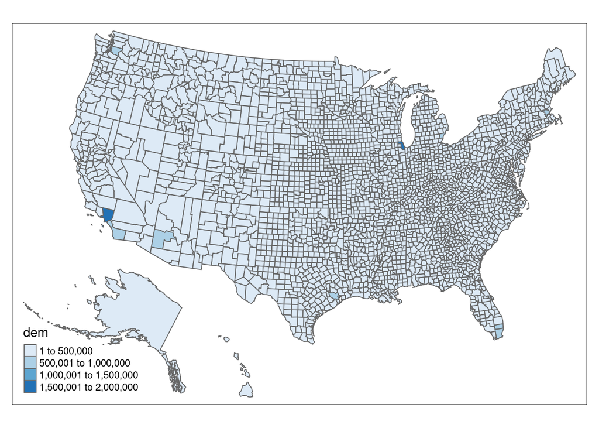

```r
tm_shape(results) +
  tm_polygons(col = 'dem', palette = 'Blues')
```

Now go back to the overview or on to the next page.